# Part 5-How many factors-10

Mingyang Cai

Part 5: Structural equation model (MIMIC SEM) How many factors?  
Keep the 0 scores (Not Applicable) in the raw RRP/QRP variables and remove 3 RRPs (`RCorrectPub`, `RPreReg` and `ROpenCode`) and 1 QRP (`QNoReSubmit`) whose percentages of `NA` answers exceed 20%.

# Packages used

The following packages are used.

```r
library(dplyr)    # Data manipulation
library(mice)     # Data imputation
library(magrittr) # Pipes
library(purrr)    # Functional programming
library(ggplot2)  # Plotting device
library(lavaan)   # Latent variable analysis
library(psych)    # Factor analysis
library(polycor)  # Polychoric correlation
library(GPArotation) #Rotation
```

# Read in the data file

I load all workspaces from the `\Workspaces\` directory in the project’s root.

```r
load("../Workspaces/1. Data import and preparation.Rdata")
load("../Workspaces/2. Data inspection.Rdata")
load("../Workspaces/3. Data imputation.Rdata")
load("../Workspaces/5. Preparation Imputed Datasets.Rdata")
```

# Setting the RNG seed

```r
set.seed(123)
```

# Combine two dichotomous misconduct items (`RRfabr` and `RRfals`)

```r
rrp <- c("RDisclFunds", "RAuthorship", "ROpenData", "RKeepRecord",
         "RDataManage", "ROpenAccess", "RCiteSource", "RErrorCheck")
qrp <- c("QAttention", "QSupervision", "QResDesign", "QUnfairRev", "QUnsubstClaims",
         "QCiteSource", "QResNotes", "QConcealDetails", "QConcealFlaws", "QSelectCites")


d50 <- d50 %>%
  map(select, -RCorrectPub_raw, -RPreReg_raw, -ROpenCode_raw, -QNoReSubmit_raw,
      -RCorrectPub, -RPreReg, -ROpenCode, -QNoReSubmit, -all_of(rrp), -all_of(qrp))

d50 <- d50 %>%
  map(~ .x %>%
        mutate_at(vars(!!!syms(paste0(rrp, "_raw"))), list(r = ~ recode(., `0` = 0))) %>%
        rename_at(vars(ends_with(("_raw_r"))), ~ gsub("_raw_r", "", .x)) %>%
        mutate_at(vars(!!!syms(paste0(qrp, "_raw"))), list(q = ~ recode(., `0` = 0))) %>%
        rename_at(vars(ends_with(("_raw_q"))), ~ gsub("_raw_q", "", .x)))

d50 <- d50 %>%
  map(~ .x %>%
        mutate(RRP_ave = rowMeans(cbind(!!!syms(rrp)), na.rm = T)) %>%
        mutate(QRP_ave = rowMeans(cbind(!!!syms(qrp)), na.rm = T)))

d50 <- d50 %>%
  map(~ .x %>%
        mutate(QRP_1 = rowSums(cbind(!!!syms(qrp)) > 4)) %>%
        mutate(QRP_1 = if_else(QRP_1 == 0, 0, 1)))

d50 <- d50 %>%
  map(~.x %>%
        mutate(RR_sum = rowSums(cbind(RRfabr, RRfals))))
```

# Test the model with one factor

```r
Model.1 <- '#latent variable definition
            QRP =~ QAttention + QSupervision + QResDesign + QUnfairRev
                 + QUnsubstClaims + QCiteSource + QResNotes + QConcealDetails
                 + QConcealFlaws + QSelectCites
                 + RDisclFunds + RAuthorship + ROpenData
                 + RKeepRecord + RDataManage + ROpenAccess
                 + RCiteSource + RErrorCheck
                 + RR_sum

            #variance and covariance
            RDisclFunds ~~ RAuthorship
'
fit.model.1 <- cfa(Model.1, data = complete(d50[[1]]), estimator = "WLSMV")
summary(fit.model.1, fit.measures = TRUE)
```

```
## lavaan 0.6-9 ended normally after 70 iterations
##
##   Estimator                                       DWLS
##   Optimization method                           NLMINB
##   Number of model parameters                        39
##
##   Number of observations                          6813
##
## Model Test User Model:
##                                               Standard      Robust
##   Test Statistic                              5446.983    6073.842
##   Degrees of freedom                               151         151
##   P-value (Chi-square)                           0.000       0.000
##   Scaling correction factor                                  0.901
##   Shift parameter                                           31.675
##        simple second-order correction
##
## Model Test Baseline Model:
##
##   Test statistic                             16182.771    7934.095
##   Degrees of freedom                               171         171
##   P-value                                        0.000       0.000
##   Scaling correction factor                                  2.063
##
## User Model versus Baseline Model:
##
##   Comparative Fit Index (CFI)                    0.669       0.237
##   Tucker-Lewis Index (TLI)                       0.625       0.136
##
##   Robust Comparative Fit Index (CFI)                            NA
##   Robust Tucker-Lewis Index (TLI)                               NA
##
## Root Mean Square Error of Approximation:
##
##   RMSEA                                          0.072       0.076
##   90 Percent confidence interval - lower         0.070       0.074
##   90 Percent confidence interval - upper         0.073       0.078
##   P-value RMSEA <= 0.05                          0.000       0.000
##
##   Robust RMSEA                                                  NA
```

[output cut: 48 more lines]

```
##    .QCiteSource       0.383    0.018   20.706    0.000
##    .QResNotes         2.274    0.044   51.422    0.000
##    .QConcealDetals    0.873    0.042   20.911    0.000
##    .QConcealFlaws     2.772    0.070   39.550    0.000
##    .QSelectCites      2.338    0.054   43.641    0.000
##    .RDisclFunds       5.085    0.116   43.771    0.000
##    .RAuthorship       3.981    0.075   53.163    0.000
##    .ROpenData         4.969    0.074   67.477    0.000
##    .RKeepRecord       4.365    0.056   78.157    0.000
##    .RDataManage       4.717    0.090   52.428    0.000
##    .ROpenAccess       4.280    0.073   58.590    0.000
##    .RCiteSource       1.833    0.082   22.244    0.000
##    .RErrorCheck       2.470    0.074   33.295    0.000
##    .RR_sum            0.314    0.006   55.709    0.000
##     QRP               0.440    0.033   13.437    0.000
```

CFI is 0.67.

# Five modifications to improve Model 1

```r
modificationindices(fit.model.1, sort. = TRUE, maximum.number = 5)
```

```
##             lhs op         rhs      mi   epc sepc.lv sepc.all sepc.nox
## 196 RKeepRecord ~~ RDataManage 420.222 1.481   1.481    0.326    0.326
## 179 RDisclFunds ~~ ROpenAccess 219.416 1.351   1.351    0.289    0.289
## 190   ROpenData ~~ RKeepRecord 207.143 0.979   0.979    0.210    0.210
## 186 RAuthorship ~~ ROpenAccess 202.624 1.063   1.063    0.258    0.258
## 192   ROpenData ~~ ROpenAccess 187.829 1.037   1.037    0.225    0.225
```

```r
Model.1.modi <- '#latent variable definition
            QRP =~ QAttention + QSupervision + QResDesign + QUnfairRev
                 + QUnsubstClaims + QCiteSource + QResNotes + QConcealDetails
                 + QConcealFlaws + QSelectCites
                 + RDisclFunds + RAuthorship + ROpenData
                 + RKeepRecord + RDataManage + ROpenAccess
                 + RCiteSource + RErrorCheck
                 + RR_sum

            #variance and covariance
            RDisclFunds ~~ RAuthorship
            RKeepRecord ~~ RDataManage
            RDisclFunds ~~ ROpenAccess
            ROpenData ~~ RKeepRecord
            RAuthorship ~~ ROpenAccess
            ROpenData ~~ ROpenAccess

'
fit.model.1.modi <- cfa(Model.1.modi, data = complete(d50[[1]]), estimator = "WLSMV")
summary(fit.model.1.modi, fit.measures = TRUE)
```

```
## lavaan 0.6-9 ended normally after 68 iterations
##
##   Estimator                                       DWLS
##   Optimization method                           NLMINB
##   Number of model parameters                        44
##
##   Number of observations                          6813
##
## Model Test User Model:
##                                               Standard      Robust
##   Test Statistic                              4115.513    4550.374
##   Degrees of freedom                               146         146
##   P-value (Chi-square)                           0.000       0.000
##   Scaling correction factor                                  0.911
##   Shift parameter                                           31.153
##        simple second-order correction
##
## Model Test Baseline Model:
##
##   Test statistic                             16182.771    7934.095
##   Degrees of freedom                               171         171
##   P-value                                        0.000       0.000
##   Scaling correction factor                                  2.063
##
## User Model versus Baseline Model:
##
##   Comparative Fit Index (CFI)                    0.752       0.433
##   Tucker-Lewis Index (TLI)                       0.710       0.336
##
##   Robust Comparative Fit Index (CFI)                            NA
##   Robust Tucker-Lewis Index (TLI)                               NA
##
## Root Mean Square Error of Approximation:
##
##   RMSEA                                          0.063       0.067
##   90 Percent confidence interval - lower         0.062       0.065
##   90 Percent confidence interval - upper         0.065       0.068
##   P-value RMSEA <= 0.05                          0.000       0.000
##
##   Robust RMSEA                                                  NA
```

[output cut: 58 more lines]

```
##    .QCiteSource       0.375    0.018   20.706    0.000
##    .QResNotes         2.224    0.044   50.031    0.000
##    .QConcealDetals    0.852    0.042   20.417    0.000
##    .QConcealFlaws     2.764    0.071   38.842    0.000
##    .QSelectCites      2.295    0.054   42.485    0.000
##    .RDisclFunds       5.267    0.118   44.452    0.000
##    .RAuthorship       4.031    0.078   51.593    0.000
##    .ROpenData         5.109    0.074   68.704    0.000
##    .RKeepRecord       4.426    0.057   77.412    0.000
##    .RDataManage       4.805    0.091   52.514    0.000
##    .ROpenAccess       4.482    0.074   60.492    0.000
##    .RCiteSource       1.847    0.084   21.897    0.000
##    .RErrorCheck       2.499    0.077   32.542    0.000
##    .RR_sum            0.314    0.006   55.701    0.000
##     QRP               0.477    0.034   14.039    0.000
```

CFI increases to 0.75.

# Test the model with two factors

```r
Model.2 <- '#latent variable definition
            QRP =~ QAttention + QSupervision + QResDesign + QUnfairRev
                 + QUnsubstClaims + QCiteSource + QResNotes + QConcealDetails
                 + QConcealFlaws + QSelectCites
                 + RR_sum
            RRP =~ RDisclFunds + RAuthorship + ROpenData
                 + RKeepRecord + RDataManage + ROpenAccess
                 + RCiteSource + RErrorCheck

            #variance and covariance
            RDisclFunds ~~ RAuthorship

'
fit.model.2 <- cfa(Model.2, data = complete(d50[[1]]), estimator = "WLSMV", std.lv=TRUE)
summary(fit.model.2, fit.measures = TRUE)
```

```
## lavaan 0.6-9 ended normally after 64 iterations
##
##   Estimator                                       DWLS
##   Optimization method                           NLMINB
##   Number of model parameters                        40
##
##   Number of observations                          6813
##
## Model Test User Model:
##                                               Standard      Robust
##   Test Statistic                              2173.002    2505.057
##   Degrees of freedom                               150         150
##   P-value (Chi-square)                           0.000       0.000
##   Scaling correction factor                                  0.877
##   Shift parameter                                           26.981
##        simple second-order correction
##
## Model Test Baseline Model:
##
##   Test statistic                             16182.771    7934.095
##   Degrees of freedom                               171         171
##   P-value                                        0.000       0.000
##   Scaling correction factor                                  2.063
##
## User Model versus Baseline Model:
##
##   Comparative Fit Index (CFI)                    0.874       0.697
##   Tucker-Lewis Index (TLI)                       0.856       0.654
##
##   Robust Comparative Fit Index (CFI)                            NA
##   Robust Tucker-Lewis Index (TLI)                               NA
##
## Root Mean Square Error of Approximation:
##
##   RMSEA                                          0.044       0.048
##   90 Percent confidence interval - lower         0.043       0.046
##   90 Percent confidence interval - upper         0.046       0.050
##   P-value RMSEA <= 0.05                          1.000       0.976
##
##   Robust RMSEA                                                  NA
```

[output cut: 52 more lines]

```
##    .QResNotes         2.190    0.045   49.070    0.000
##    .QConcealDetals    0.836    0.042   20.050    0.000
##    .QConcealFlaws     2.776    0.072   38.396    0.000
##    .QSelectCites      2.250    0.054   41.339    0.000
##    .RR_sum            0.314    0.006   55.693    0.000
##    .RDisclFunds       3.818    0.130   29.284    0.000
##    .RAuthorship       3.386    0.073   46.504    0.000
##    .ROpenData         3.960    0.089   44.663    0.000
##    .RKeepRecord       4.025    0.063   64.023    0.000
##    .RDataManage       4.023    0.098   41.097    0.000
##    .ROpenAccess       3.437    0.081   42.641    0.000
##    .RCiteSource       1.557    0.066   23.590    0.000
##    .RErrorCheck       1.955    0.059   33.262    0.000
##     QRP               1.000
##     RRP               1.000
```

The CFI is 0.87.

# Five modifications to improve Model 2

```r
modificationindices(fit.model.2, sort. = TRUE, maximum.number = 5)
```

```
##             lhs op           rhs      mi   epc sepc.lv sepc.all sepc.nox
## 222 RKeepRecord ~~   RDataManage 211.413 1.132   1.132    0.281    0.281
## 54          RRP =~    QUnfairRev 193.610 0.116   0.116    0.167    0.167
## 43          QRP =~   RDisclFunds 140.578 0.362   0.362    0.150    0.150
## 59          RRP =~ QConcealFlaws 119.529 0.236   0.236    0.127    0.127
## 125  QUnfairRev ~~   ROpenAccess 107.233 0.222   0.222    0.186    0.186
```

```r
Model.2.modi <- '#latent variable definition
            QRP =~ QAttention + QSupervision + QResDesign + QUnfairRev
                 + QUnsubstClaims + QCiteSource + QResNotes + QConcealDetails
                 + QConcealFlaws + QSelectCites
                 + RR_sum + RDisclFunds
            RRP =~ RDisclFunds + RAuthorship + ROpenData
                 + RKeepRecord + RDataManage + ROpenAccess
                 + RCiteSource + RErrorCheck + QUnfairRev
                 + QConcealFlaws

            #variance and covariance
            RDisclFunds ~~ RAuthorship
            RKeepRecord ~~ RDataManage
            QUnfairRev ~~ ROpenAccess

'
fit.model.2.modi <- cfa(Model.2.modi, data = complete(d50[[1]]), estimator = "WLSMV", std.lv=TRUE)
summary(fit.model.2.modi, fit.measures = TRUE)
```

```
## lavaan 0.6-9 ended normally after 73 iterations
##
##   Estimator                                       DWLS
##   Optimization method                           NLMINB
##   Number of model parameters                        45
##
##   Number of observations                          6813
##
## Model Test User Model:
##                                               Standard      Robust
##   Test Statistic                              1429.944    1704.603
##   Degrees of freedom                               145         145
##   P-value (Chi-square)                           0.000       0.000
##   Scaling correction factor                                  0.852
##   Shift parameter                                           25.300
##        simple second-order correction
##
## Model Test Baseline Model:
##
##   Test statistic                             16182.771    7934.095
##   Degrees of freedom                               171         171
##   P-value                                        0.000       0.000
##   Scaling correction factor                                  2.063
##
## User Model versus Baseline Model:
##
##   Comparative Fit Index (CFI)                    0.920       0.799
##   Tucker-Lewis Index (TLI)                       0.905       0.763
##
##   Robust Comparative Fit Index (CFI)                            NA
##   Robust Tucker-Lewis Index (TLI)                               NA
##
## Root Mean Square Error of Approximation:
##
##   RMSEA                                          0.036       0.040
##   90 Percent confidence interval - lower         0.034       0.038
##   90 Percent confidence interval - upper         0.038       0.041
##   P-value RMSEA <= 0.05                          1.000       1.000
##
##   Robust RMSEA                                                  NA
```

[output cut: 59 more lines]

```
##    .QResNotes         2.149    0.045   47.835    0.000
##    .QConcealDetals    0.830    0.042   19.852    0.000
##    .QConcealFlaws     2.816    0.071   39.713    0.000
##    .QSelectCites      2.232    0.055   40.606    0.000
##    .RR_sum            0.314    0.006   55.689    0.000
##    .RDisclFunds       4.080    0.122   33.412    0.000
##    .RAuthorship       3.277    0.073   44.964    0.000
##    .ROpenData         3.896    0.091   42.827    0.000
##    .RKeepRecord       4.156    0.062   66.840    0.000
##    .RDataManage       4.265    0.100   42.591    0.000
##    .ROpenAccess       3.339    0.083   40.468    0.000
##    .RCiteSource       1.488    0.064   23.318    0.000
##    .RErrorCheck       1.860    0.058   32.210    0.000
##     QRP               1.000
##     RRP               1.000
```

The CFI now is 0.92.

# Investigate model with three factors with explanatory factor analysis

```r
efa.fit.3 <- complete(d50[[1]]) %>% extract(c(114:132)) %>% hetcor(ML = TRUE) %>% use_series(correlations) %>% fa(., nfactors = 3, rotate = "promax")
print(efa.fit.3)
```

```
## Factor Analysis using method =  minres
## Call: fa(r = ., nfactors = 3, rotate = "promax")
## Standardized loadings (pattern matrix) based upon correlation matrix
##                   MR2   MR1   MR3     h2   u2 com
## RDisclFunds      0.12  0.48  0.08 0.2987 0.70 1.2
## RAuthorship     -0.07  0.53 -0.03 0.2668 0.73 1.0
## ROpenData        0.04  0.34  0.26 0.2365 0.76 1.9
## RKeepRecord      0.02  0.03  0.54 0.3001 0.70 1.0
## RDataManage      0.11  0.11  0.58 0.3987 0.60 1.2
## ROpenAccess      0.04  0.58 -0.05 0.3361 0.66 1.0
## RCiteSource     -0.10  0.53  0.03 0.2886 0.71 1.1
## RErrorCheck     -0.08  0.48  0.19 0.3107 0.69 1.4
## QAttention       0.42 -0.02  0.07 0.1798 0.82 1.1
## QSupervision     0.28  0.21 -0.11 0.1428 0.86 2.2
## QResDesign       0.54 -0.12  0.17 0.2965 0.70 1.3
## QUnfairRev       0.28  0.29 -0.15 0.1909 0.81 2.5
## QUnsubstClaims   0.55 -0.08  0.05 0.2886 0.71 1.1
## QCiteSource      0.43 -0.04 -0.07 0.1889 0.81 1.1
## QResNotes        0.46 -0.04  0.02 0.2095 0.79 1.0
## QConcealDetails  0.48  0.08  0.00 0.2547 0.75 1.1
## QConcealFlaws    0.38  0.12  0.05 0.1765 0.82 1.2
## QSelectCites     0.43 -0.01  0.00 0.1851 0.81 1.0
## RR_sum           0.05 -0.04  0.00 0.0035 1.00 2.0
##
##                        MR2  MR1  MR3
## SS loadings           1.95 1.74 0.87
## Proportion Var        0.10 0.09 0.05
## Cumulative Var        0.10 0.19 0.24
## Proportion Explained  0.43 0.38 0.19
## Cumulative Proportion 0.43 0.81 1.00
##
##  With factor correlations of
##       MR2  MR1   MR3
## MR2  1.00 0.18 -0.03
## MR1  0.18 1.00  0.28
## MR3 -0.03 0.28  1.00
##
## Mean item complexity =  1.3
## Test of the hypothesis that 3 factors are sufficient.
##
## The degrees of freedom for the null model are  171  and the objective function was  2.26
## The degrees of freedom for the model are 117  and the objective function was  0.17
##
## The root mean square of the residuals (RMSR) is  0.02
## The df corrected root mean square of the residuals is  0.03
##
## Fit based upon off diagonal values = 0.97
## Measures of factor score adequacy
##                                                    MR2  MR1  MR3
## Correlation of (regression) scores with factors   0.85 0.84 0.75
## Multiple R square of scores with factors          0.72 0.71 0.56
## Minimum correlation of possible factor scores     0.43 0.42 0.13
```

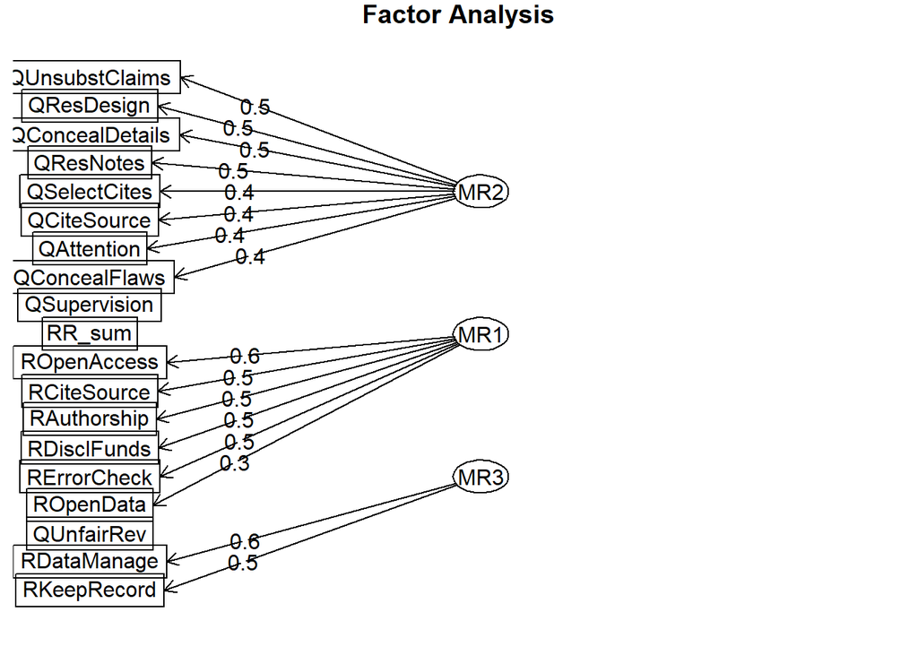

```r
fa.diagram(efa.fit.3)
```

The factor path plot shows the structure of the model with three factors. `MR2` is the QRP factor, `MR1` is one RRP factor (RRP.1) and `MR3` is the other RRP factor (RRP.2). In this plot, the variable `QUnfairRev` is an indicator of RRP.1. However, since the loading of `QUnfairRev` is 0.29 on RRP.1 and is 0.28 on QRP. I still treat `QUnfairRev` as an indicator of QRP.

# Perform confirmatory factor analysis with three factors

```r
Model.3 <- '#latent variable definition
            QRP =~ QAttention + QSupervision + QResDesign + QUnfairRev
                 + QUnsubstClaims + QCiteSource + QResNotes + QConcealDetails
                 + QConcealFlaws + QSelectCites
                 + RR_sum

            RRP.1 =~ RCiteSource + ROpenAccess + RDisclFunds + RAuthorship
                   + RErrorCheck + ROpenData

            RRP.2 =~ RKeepRecord + RDataManage

            #variance and covariance
            RDisclFunds ~~ RAuthorship

'
fit.model.3 <- cfa(Model.3, data = complete(d50[[1]]), estimator = "WLSMV")
summary(fit.model.3, fit.measures = TRUE)
```

```
## lavaan 0.6-9 ended normally after 90 iterations
##
##   Estimator                                       DWLS
##   Optimization method                           NLMINB
##   Number of model parameters                        42
##
##   Number of observations                          6813
##
## Model Test User Model:
##                                               Standard      Robust
##   Test Statistic                              1954.671    2301.002
##   Degrees of freedom                               148         148
##   P-value (Chi-square)                           0.000       0.000
##   Scaling correction factor                                  0.859
##   Shift parameter                                           25.714
##        simple second-order correction
##
## Model Test Baseline Model:
##
##   Test statistic                             16182.771    7934.095
##   Degrees of freedom                               171         171
##   P-value                                        0.000       0.000
##   Scaling correction factor                                  2.063
##
## User Model versus Baseline Model:
##
##   Comparative Fit Index (CFI)                    0.887       0.723
##   Tucker-Lewis Index (TLI)                       0.870       0.680
##
##   Robust Comparative Fit Index (CFI)                            NA
##   Robust Tucker-Lewis Index (TLI)                               NA
##
## Root Mean Square Error of Approximation:
##
##   RMSEA                                          0.042       0.046
##   90 Percent confidence interval - lower         0.041       0.045
##   90 Percent confidence interval - upper         0.044       0.048
##   P-value RMSEA <= 0.05                          1.000       1.000
##
##   Robust RMSEA                                                  NA
```

[output cut: 57 more lines]

```
##    .QConcealDetals    0.836    0.042   20.042    0.000
##    .QConcealFlaws     2.776    0.072   38.391    0.000
##    .QSelectCites      2.251    0.054   41.340    0.000
##    .RR_sum            0.314    0.006   55.693    0.000
##    .RCiteSource       1.535    0.065   23.608    0.000
##    .ROpenAccess       3.318    0.082   40.627    0.000
##    .RDisclFunds       3.681    0.134   27.554    0.000
##    .RAuthorship       3.320    0.074   45.095    0.000
##    .RErrorCheck       1.948    0.059   33.162    0.000
##    .ROpenData         3.979    0.089   44.765    0.000
##    .RKeepRecord       3.500    0.085   41.356    0.000
##    .RDataManage       2.338    0.188   12.419    0.000
##     QRP               0.497    0.035   14.358    0.000
##     RRP.1             0.340    0.050    6.809    0.000
##     RRP.2             0.956    0.084   11.425    0.000
```

The CFI is 0.89.

# Five modifications to improve Model 3

```r
modificationindices(fit.model.3, sort. = TRUE, maximum.number = 5)
```

```
##            lhs op           rhs      mi    epc sepc.lv sepc.all sepc.nox
## 57       RRP.1 =~    QUnfairRev 217.600  0.212   0.123    0.178    0.178
## 48         QRP =~   RDisclFunds 144.098  0.539   0.380    0.158    0.158
## 62       RRP.1 =~ QConcealFlaws 118.258  0.403   0.235    0.127    0.127
## 143 QUnfairRev ~~   ROpenAccess 105.493  0.220   0.220    0.188    0.188
## 59       RRP.1 =~   QCiteSource  97.802 -0.132  -0.077   -0.119   -0.119
```

```r
Model.3.modi <- '#latent variable definition
            QRP =~ QAttention + QSupervision + QResDesign + QUnfairRev
                 + QUnsubstClaims + QCiteSource + QResNotes + QConcealDetails
                 + QConcealFlaws + QSelectCites + RDisclFunds
                 + RR_sum

            RRP.1 =~ RCiteSource + ROpenAccess + RDisclFunds + RAuthorship
                   + RErrorCheck + ROpenData + QUnfairRev + QConcealFlaws
                   + QCiteSource

            RRP.2 =~ RKeepRecord + RDataManage

            #variance and covariance
            RDisclFunds ~~ RAuthorship
            QUnfairRev ~~ ROpenAccess

'
fit.model.3.modi <- cfa(Model.3.modi, data = complete(d50[[1]]), estimator = "WLSMV")
summary(fit.model.3.modi, fit.measures = TRUE)
```

```
## lavaan 0.6-9 ended normally after 90 iterations
##
##   Estimator                                       DWLS
##   Optimization method                           NLMINB
##   Number of model parameters                        47
##
##   Number of observations                          6813
##
## Model Test User Model:
##                                               Standard      Robust
##   Test Statistic                              1334.536    1672.055
##   Degrees of freedom                               143         143
##   P-value (Chi-square)                           0.000       0.000
##   Scaling correction factor                                  0.809
##   Shift parameter                                           22.483
##        simple second-order correction
##
## Model Test Baseline Model:
##
##   Test statistic                             16182.771    7934.095
##   Degrees of freedom                               171         171
##   P-value                                        0.000       0.000
##   Scaling correction factor                                  2.063
##
## User Model versus Baseline Model:
##
##   Comparative Fit Index (CFI)                    0.926       0.803
##   Tucker-Lewis Index (TLI)                       0.911       0.764
##
##   Robust Comparative Fit Index (CFI)                            NA
##   Robust Tucker-Lewis Index (TLI)                               NA
##
## Root Mean Square Error of Approximation:
##
##   RMSEA                                          0.035       0.040
##   90 Percent confidence interval - lower         0.033       0.038
##   90 Percent confidence interval - upper         0.037       0.041
##   P-value RMSEA <= 0.05                          1.000       1.000
##
##   Robust RMSEA                                                  NA
```

[output cut: 63 more lines]

```
##    .QConcealDetals    0.832    0.042   19.932    0.000
##    .QConcealFlaws     2.816    0.071   39.794    0.000
##    .QSelectCites      2.238    0.055   40.823    0.000
##    .RDisclFunds       4.073    0.122   33.387    0.000
##    .RR_sum            0.314    0.006   55.690    0.000
##    .RCiteSource       1.467    0.064   23.061    0.000
##    .ROpenAccess       3.325    0.082   40.478    0.000
##    .RAuthorship       3.251    0.073   44.601    0.000
##    .RErrorCheck       1.839    0.058   31.944    0.000
##    .ROpenData         3.897    0.091   43.043    0.000
##    .RKeepRecord       3.497    0.085   41.001    0.000
##    .RDataManage       2.348    0.189   12.432    0.000
##     QRP               0.516    0.035   14.769    0.000
##     RRP.1             0.409    0.053    7.689    0.000
##     RRP.2             0.959    0.084   11.381    0.000
```

The CFI is now 0.93.